# week_11_lm_predictions_linear

## CPMINF 2100 Week 11

### Making predictions with Linear Models

We will make predictiosn for the linear relationship example.

## Import Modules

```python
import numpy as np
import pandas as pd
import matplotlib.pyplot as plt

import seaborn as sns
```

```python
import statsmodels.formula.api as smf
```

## Read data

```python
df = pd.read_csv("week_11_linear_data.csv")
```

```python
df
```

|  | x | trend | y | true_intercept | true_slope | true_sigma |
| --- | --- | --- | --- | --- | --- | --- |
| 0 | -3.00 | 4.750 | 6.030315 | 0.25 | -1.5 | 1.25 |
| 1 | -2.25 | 3.625 | 1.457911 | 0.25 | -1.5 | 1.25 |
| 2 | -1.50 | 2.500 | 2.388383 | 0.25 | -1.5 | 1.25 |
| 3 | -0.75 | 1.375 | 0.007815 | 0.25 | -1.5 | 1.25 |
| 4 | 0.00 | 0.250 | 0.651244 | 0.25 | -1.5 | 1.25 |
| 5 | 0.75 | -0.875 | -2.254007 | 0.25 | -1.5 | 1.25 |
| 6 | 1.50 | -2.000 | -2.969992 | 0.25 | -1.5 | 1.25 |
| 7 | 2.25 | -3.125 | -3.537097 | 0.25 | -1.5 | 1.25 |
| 8 | 3.00 | -4.250 | -6.063282 | 0.25 | -1.5 | 1.25 |

## Fit the linear model

Lets fit the linear model with the linear relationship between the SINGLE input x and the MEANT OUPUT of y.

```python
lm_fit = smf.ols(formula="y ~ x", data=df).fit()
```

```python
print(lm_fit.summary())
```

```
                            OLS Regression Results
==============================================================================
Dep. Variable:                      y   R-squared:                       0.918
Model:                            OLS   Adj. R-squared:                  0.907
Method:                 Least Squares   F-statistic:                     78.82
Date:                Tue, 12 Nov 2024   Prob (F-statistic):           4.66e-05
Time:                        15:29:51   Log-Likelihood:                -12.580
No. Observations:                   9   AIC:                             29.16
Df Residuals:                       7   BIC:                             29.55
Df Model:                           1
Covariance Type:            nonrobust
==============================================================================
                 coef    std err          t      P>|t|      [0.025      0.975]
------------------------------------------------------------------------------
Intercept     -0.4765      0.370     -1.288      0.239      -1.352       0.398
x             -1.6964      0.191     -8.878      0.000      -2.148      -1.245
==============================================================================
Omnibus:                        0.301   Durbin-Watson:                   2.978
Prob(Omnibus):                  0.860   Jarque-Bera (JB):                0.330
Skew:                          -0.315   Prob(JB):                        0.848
Kurtosis:                       2.306   Cond. No.                         1.94
==============================================================================

Notes:
[1] Standard Errors assume that the covariance matrix of the errors is correctly specified.
```

## Making predictions

Unfortunately, predictions are the LEAST used tools for interpreting model behavior!!

Predictions can be made on data that DO NOT INCLUDE observed outputs!!!

We can create our own data sets and visualize the predictive trends, predictive uncertainty, the predictive behavior for ANY input value!!!

Lets create a dataset that has MORE input locations than the training set.

```python
df_viz = pd.DataFrame({"x": np.linspace(df.x.min()-0.1, df.x.max()+0.1, num=101)})
```

```python
df_viz
```

|  | x |
| --- | --- |
| 0 | -3.100 |
| 1 | -3.038 |
| 2 | -2.976 |
| 3 | -2.914 |
| 4 | -2.852 |
| ... | ... |
| 96 | 2.852 |
| 97 | 2.914 |
| 98 | 2.976 |
| 99 | 3.038 |
| 100 | 3.100 |

101 rows × 1 columns

```python
df
```

|  | x | trend | y | true_intercept | true_slope | true_sigma |
| --- | --- | --- | --- | --- | --- | --- |
| 0 | -3.00 | 4.750 | 6.030315 | 0.25 | -1.5 | 1.25 |
| 1 | -2.25 | 3.625 | 1.457911 | 0.25 | -1.5 | 1.25 |
| 2 | -1.50 | 2.500 | 2.388383 | 0.25 | -1.5 | 1.25 |
| 3 | -0.75 | 1.375 | 0.007815 | 0.25 | -1.5 | 1.25 |
| 4 | 0.00 | 0.250 | 0.651244 | 0.25 | -1.5 | 1.25 |
| 5 | 0.75 | -0.875 | -2.254007 | 0.25 | -1.5 | 1.25 |
| 6 | 1.50 | -2.000 | -2.969992 | 0.25 | -1.5 | 1.25 |
| 7 | 2.25 | -3.125 | -3.537097 | 0.25 | -1.5 | 1.25 |
| 8 | 3.00 | -4.250 | -6.063282 | 0.25 | -1.5 | 1.25 |

We can ask **WHAT IF** questions?? What if the INPUT is at a NEW value that we DID NOT see previously??

What wil the OUPUT BE????

The statsmodels fitted object includes the .predict() method. This method lets you PREDICT a new data set GIVEN the FITTED MODEL!!!

Make the prediction and assign the lm_pred object.

```python
lm_pred = lm_fit.predict(df_viz)
```

```python
lm_pred
```

```
0      4.782316
1      4.677139
2      4.571962
3      4.466785
4      4.361608
         ...
96    -5.314655
97    -5.419832
98    -5.525008
99    -5.630185
100   -5.735362
Length: 101, dtype: float64
```

```python
lm_pred.size
```

```
101
```

```python
lm_pred.shape
```

```
(101,)
```

Lets make a copy of the visualization Df and add the prediction to this copy.

```python
df_viz_copy = df_viz.copy()
```

```python
df_viz_copy["pred_trend"] = pd.Series(lm_pred, index=df_viz.index)
```

```python
df_viz_copy
```

|  | x | pred_trend |
| --- | --- | --- |
| 0 | -3.100 | 4.782316 |
| 1 | -3.038 | 4.677139 |
| 2 | -2.976 | 4.571962 |
| 3 | -2.914 | 4.466785 |
| 4 | -2.852 | 4.361608 |
| ... | ... | ... |
| 96 | 2.852 | -5.314655 |
| 97 | 2.914 | -5.419832 |
| 98 | 2.976 | -5.525008 |
| 99 | 3.038 | -5.630185 |
| 100 | 3.100 | -5.735362 |

101 rows × 2 columns

We can visualize the predicted TREND with respect to the INPUT.

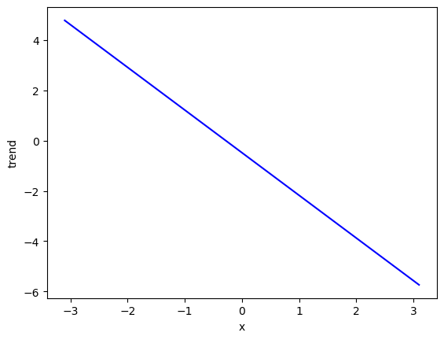

```python
fig, ax = plt.subplots()

ax.plot(df_viz_copy.x, df_viz_copy.pred_trend, color="b")

ax.set_xlabel("x")
ax.set_ylabel("trend")

plt.show()
```

Include the TRAINING set as a scatter plot.

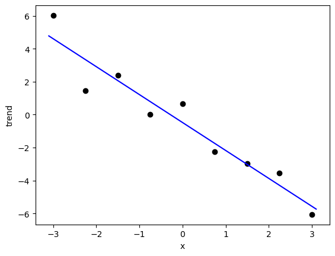

```python
fig, ax = plt.subplots()

ax.plot(df_viz_copy.x, df_viz_copy.pred_trend, color="b")
ax.scatter(x=df.x, y=df.y, color="k")

ax.set_xlabel("x")
ax.set_ylabel("trend")

plt.show()
```

Because this is a TOY PROBLEM and we generated the data...we KNOW the real answer or the TRUE TREND.

```python
df
```

|  | x | trend | y | true_intercept | true_slope | true_sigma |
| --- | --- | --- | --- | --- | --- | --- |
| 0 | -3.00 | 4.750 | 6.030315 | 0.25 | -1.5 | 1.25 |
| 1 | -2.25 | 3.625 | 1.457911 | 0.25 | -1.5 | 1.25 |
| 2 | -1.50 | 2.500 | 2.388383 | 0.25 | -1.5 | 1.25 |
| 3 | -0.75 | 1.375 | 0.007815 | 0.25 | -1.5 | 1.25 |
| 4 | 0.00 | 0.250 | 0.651244 | 0.25 | -1.5 | 1.25 |
| 5 | 0.75 | -0.875 | -2.254007 | 0.25 | -1.5 | 1.25 |
| 6 | 1.50 | -2.000 | -2.969992 | 0.25 | -1.5 | 1.25 |
| 7 | 2.25 | -3.125 | -3.537097 | 0.25 | -1.5 | 1.25 |
| 8 | 3.00 | -4.250 | -6.063282 | 0.25 | -1.5 | 1.25 |

```python
my_intercept = np.unique(df.true_intercept)
```

```python
my_slope = np.unique(df.true_slope)
```

Display the TRUE TREND, the TRUE MEAN relationship to the INPUT with the PREDICTED TREND.

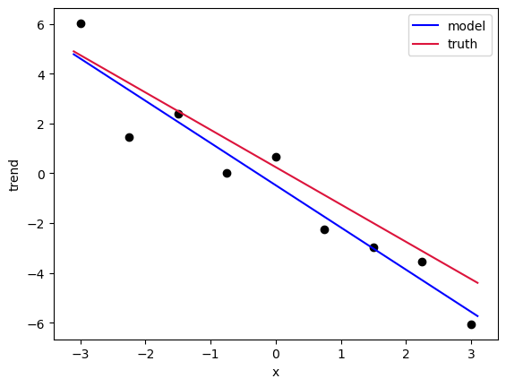

```python
fig, ax = plt.subplots()

ax.plot(df_viz_copy.x, df_viz_copy.pred_trend, color="b", label="model")
ax.plot(df_viz_copy.x, my_intercept+my_slope*df_viz_copy.x, color="crimson", label="truth")
ax.scatter(x=df.x, y=df.y, color="k")

ax.set_xlabel("x")
ax.set_ylabel("trend")

ax.legend()

plt.show()
```

We will NEVER know the TRUE relationship...we must ALWAYS include the CI on the TREND!!

We must always represent the UNCERTAINTY on the TREND given the fitted data!!!!

We will use statsmodels to pull out the predictive uncertainty!!!

statsmodels provides a 2 step process for extracting uncertainty on the predictions.

Step 1: Call the get_prediction() method on the fitted object.

```python
predictions = lm_fit.get_prediction(df_viz)
```

```python
type(predictions)
```

```
statsmodels.regression._prediction.PredictionResults
```

Step 2: Call the .summary_frame() method on the Prediction Object.

```python
lm_pred_summary = predictions.summary_frame()
```

```python
lm_pred_summary
```

|  | mean | mean_se | mean_ci_lower | mean_ci_upper | obs_ci_lower | obs_ci_upper |
| --- | --- | --- | --- | --- | --- | --- |
| 0 | 4.782316 | 0.698434 | 3.130782 | 6.433850 | 1.681036 | 7.883595 |
| 1 | 4.677139 | 0.688415 | 3.049296 | 6.304981 | 1.588411 | 7.765866 |
| 2 | 4.571962 | 0.678455 | 2.967672 | 6.176252 | 1.495582 | 7.648342 |
| 3 | 4.466785 | 0.668556 | 2.885902 | 6.047668 | 1.402546 | 7.531024 |
| 4 | 4.361608 | 0.658721 | 2.803980 | 5.919237 | 1.309302 | 7.413915 |
| ... | ... | ... | ... | ... | ... | ... |
| 96 | -5.314655 | 0.658721 | -6.872283 | -3.757026 | -8.366961 | -2.262349 |
| 97 | -5.419832 | 0.668556 | -7.000715 | -3.838948 | -8.484070 | -2.355593 |
| 98 | -5.525008 | 0.678455 | -7.129298 | -3.920718 | -8.601388 | -2.448628 |
| 99 | -5.630185 | 0.688415 | -7.258028 | -4.002343 | -8.718913 | -2.541458 |
| 100 | -5.735362 | 0.698434 | -7.386896 | -4.083828 | -8.836641 | -2.634083 |

101 rows × 6 columns

Visualize the 95% CI on the MEAN OUTPUT using RIBBONS!!!

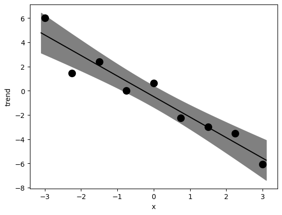

```python
fig, ax = plt.subplots()

## confidence interval - the uncertainty on the mean output
ax.fill_between(df_viz_copy.x,
               lm_pred_summary.mean_ci_lower, lm_pred_summary.mean_ci_upper,
               facecolor="grey", edgecolor="grey")

## output mean - the predictive trend - the best fit line
ax.plot(df_viz_copy.x, lm_pred_summary["mean"], color="k", linewidth=1.5)

## include the training data
ax.scatter(df.x, df.y, color="k", s=100)

## set the labels

ax.set_xlabel("x")
ax.set_ylabel("trend")

plt.show()
```

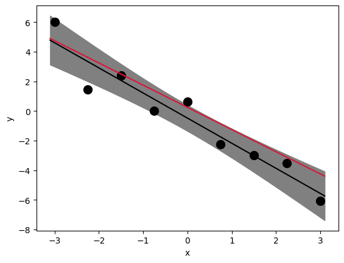

```python
fig, ax = plt.subplots()

## include the TRUE TREND
ax.plot(df_viz_copy.x, my_intercept+my_slope*df_viz_copy.x, color="crimson", linewidth=1.5)

## confidence interval - the uncertainty on the mean output
ax.fill_between(df_viz_copy.x,
               lm_pred_summary.mean_ci_lower, lm_pred_summary.mean_ci_upper,
               facecolor="grey", edgecolor="grey")

## output mean - the predictive trend - the best fit line
ax.plot(df_viz_copy.x, lm_pred_summary["mean"], color="k", linewidth=1.5)

## include the training data
ax.scatter(df.x, df.y, color="k", s=100)

## set the labels

ax.set_xlabel("x")
ax.set_ylabel("y")

plt.show()
```

But this is not the complete story...

This is just expressing the UNCERTAINTY on the AVG!! The uncertainty on the MEAN output!!

But we also have the SIGMA parameter!!!!

```python
lm_pred_summary
```

|  | mean | mean_se | mean_ci_lower | mean_ci_upper | obs_ci_lower | obs_ci_upper |
| --- | --- | --- | --- | --- | --- | --- |
| 0 | 4.782316 | 0.698434 | 3.130782 | 6.433850 | 1.681036 | 7.883595 |
| 1 | 4.677139 | 0.688415 | 3.049296 | 6.304981 | 1.588411 | 7.765866 |
| 2 | 4.571962 | 0.678455 | 2.967672 | 6.176252 | 1.495582 | 7.648342 |
| 3 | 4.466785 | 0.668556 | 2.885902 | 6.047668 | 1.402546 | 7.531024 |
| 4 | 4.361608 | 0.658721 | 2.803980 | 5.919237 | 1.309302 | 7.413915 |
| ... | ... | ... | ... | ... | ... | ... |
| 96 | -5.314655 | 0.658721 | -6.872283 | -3.757026 | -8.366961 | -2.262349 |
| 97 | -5.419832 | 0.668556 | -7.000715 | -3.838948 | -8.484070 | -2.355593 |
| 98 | -5.525008 | 0.678455 | -7.129298 | -3.920718 | -8.601388 | -2.448628 |
| 99 | -5.630185 | 0.688415 | -7.258028 | -4.002343 | -8.718913 | -2.541458 |
| 100 | -5.735362 | 0.698434 | -7.386896 | -4.083828 | -8.836641 | -2.634083 |

101 rows × 6 columns

We need to include the PREDICTION INTERVAL as a SECOND RIBBON in our visualizations for regression problems!!

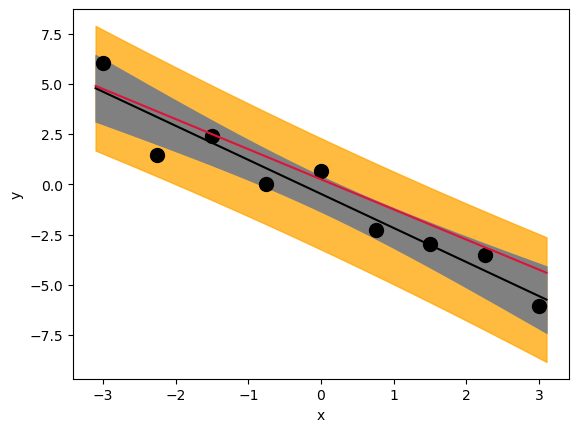

```python
fig, ax = plt.subplots()

## prediction interval = the uncertainty on a single measurement (observation)
ax.fill_between(df_viz_copy.x,
               lm_pred_summary.obs_ci_lower, lm_pred_summary.obs_ci_upper,
               facecolor="orange", alpha=0.75, edgecolor="orange")

## include the TRUE TREND
ax.plot(df_viz_copy.x, my_intercept+my_slope*df_viz_copy.x, color="crimson", linewidth=1.5)

## confidence interval - the uncertainty on the mean output
ax.fill_between(df_viz_copy.x,
               lm_pred_summary.mean_ci_lower, lm_pred_summary.mean_ci_upper,
               facecolor="grey", edgecolor="grey")

## output mean - the predictive trend - the best fit line
ax.plot(df_viz_copy.x, lm_pred_summary["mean"], color="k", linewidth=1.5)

## include the training data
ax.scatter(df.x, df.y, color="k", s=100)

## set the labels

ax.set_xlabel("x")
ax.set_ylabel("y")

plt.show()
```